# Studying Predictive Factors for Patients' Missing their Scheduled Medical Appointments in Brazil

by Osama Mohamed Naguib

## **Research Questions:**

#### Q1: Does receiveing SMS message affect the Commitment of patients to their Scheduled medical appoitnments (No-Show)?

#### Q 2: Do Age groups affect No-show incidences?

#### Q 3: Do Leading Days ( time between scheduling date and appoitnment date) affect Patients' commitment to their medical appoitnments?

#### Q 4: Do accompanies medical conditions or being on a schoolarship affect Patients' commitment to their medical appoitnments?

## **Dataset Overview:**

- Dataset has over 110'000 observations for patients schdeduled medical appointments data; including the following features:
- 'Gender', 'ScheduledDay', 'AppointmentDay', 'Age', 'Neighbourhood', 'Scholarship', 'Hipertension','Diabetes', 'Alcoholism', 'Handcap', 'SMS_received', 'No-show'
- We will investigate the correlation between most of these independent variables with the depedent variable "the missed appointments" ~NO-Show incidences).

```python
# import all packages and set plots to be embedded inline
import numpy as np
import pandas as pd
import matplotlib.pyplot as plt
import seaborn as sb

%matplotlib inline

# suppress warnings from final output
import warnings
warnings.simplefilter("ignore")
```

```python
# load in the dataset into a pandas dataframe
df_raw = pd.read_csv('No_Show_Cleaned.csv')

df_raw.drop(['patientid', 'appointmentid','neighbourhood','scheduledday','appointmentday'], axis=1, inplace=True)
```

> Note that the above cells have been set as "Skip"-type slides. That means that when the notebook is rendered as http slides, those cells won't show up.

## Exploring the dataset main characterstics - **"Univariate Exploration"**

First we are going to investigate the dataset main characterstics of each feature all at once with a custom function, then we are going to focus on the major insights one by one.

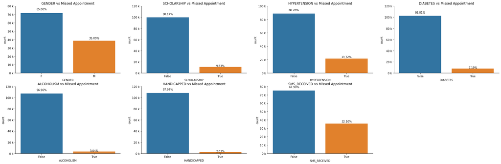

```python
# opening an empty list called n and configuring the chart size;
# optionaly we could add a color palette and style too, but we keep omit them this time for a simpler charts
n = 0
plt.figure(figsize=[32,10])
# color = sb.color_palette()[1]
# sb.set(style="white")
# Looping though columns and passing conditions to spot the categorical variables only
for c in df_raw.columns:
    if  2 <df_raw.groupby(c)['missed_appoint'].value_counts().shape[0]<5:
        # group_and_value_counts = df_raw.groupby(c)['missed_appoint'].value_counts(1).unstack()
        value_counts = df_raw[c].value_counts(1)
        # Selecting only boolean columns though condition, then to print the main value percentage of the total


        n = 1 + n

        # Configuring subplots using the variable n to determine chart number
        plt.subplot(2,4,n)

        # Ordering values for categorical varibales
        order = df_raw[c].value_counts().index

        # Plotting countplot chart using seaborn
        ax = sb.countplot(x=df_raw[c], order=order)
        plt.title(df_raw[c].name.upper() + ' vs Missed Appointment')
        # Assgining a new variabe p for the total row number
        p = df_raw[c].shape[0]

        # Assgining a new variabe counts for the value_counts of the categorical column
        counts = df_raw[c].value_counts()

        # We Can add a custom title too to each chart uing the following code, but we omit it; as  x-axis label do the job apprperiately
        # plt.title = (df_raw[c].name.upper(), " Distribution")

        # Adding x-axis label usign the capitalized name of the column
        plt.xlabel(df_raw[c].name.upper())

        # Setting yticks to show thousands as K instead of 000, to make the chart looks more neat.
        ax.set_yticks(ax.get_yticks().tolist())
        ax.set_yticklabels(['{:,} k'.format(int(x/1000)) for x in ax.get_yticks().tolist()])

        # Looping again to calculate and plot the percentage of each value_counts of each categorical variable
        for i in range(counts.shape[0]):
            # Selecting specific count for each column
            count = counts.iloc[i]
            # Calculating, formating the printing the percentage (proportion) of each value count versus the entire category
            pct = '{:0.2f}%'.format(100*count/p)
            # Specifing where to print this percentage in the chart; just above each column
            plt.text(i, count+(count*.045), pct, ha='center')
            # Removing upper and right chart margins for clearer and pilished view
            sb.despine();
```

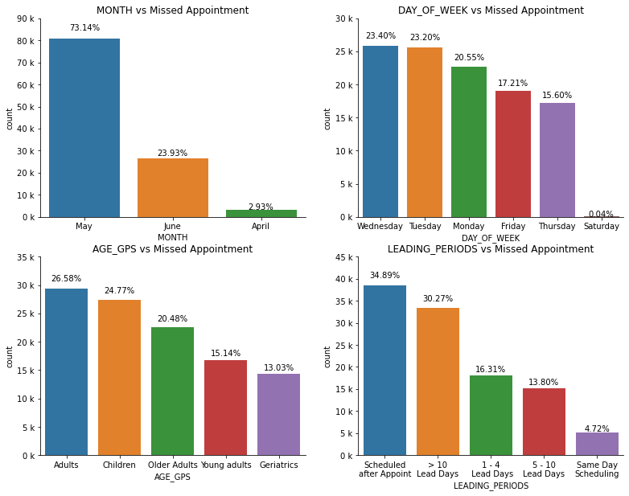

```python
# opening an empty list called n and configuring the chart size;
# optionaly we could add a color palette and style too, but we keep omit them this time for a simpler charts
n = 0
plt.figure(figsize=[13,10])
# color = sb.color_palette()[1]
# sb.set(style="white")
# Looping though columns and passing conditions to spot the categorical variables only
for c in df_raw.columns:
    if  5 <df_raw.groupby(c)['missed_appoint'].value_counts().shape[0]<20:
        # group_and_value_counts = df_raw.groupby(c)['missed_appoint'].value_counts(1).unstack()
        value_counts = df_raw[c].value_counts(1)
        # Selecting only boolean columns though condition, then to print the main value percentage of the total


        n = 1 + n

        # Configuring subplots using the variable n to determine chart number
        plt.subplot(2,2,n)

        # Ordering values for categorical varibales
        order = df_raw[c].value_counts().index

        # Plotting countplot chart using seaborn
        ax = sb.countplot(x=df_raw[c], order=order)
        plt.title(df_raw[c].name.upper() + ' vs Missed Appointment')
        # Assgining a new variabe p for the total row number
        p = df_raw[c].shape[0]

        # Assgining a new variabe counts for the value_counts of the categorical column
        counts = df_raw[c].value_counts()

        # We Can add a custom title too to each chart uing the following code, but we omit it; as  x-axis label do the job apprperiately
        # plt.title = (df_raw[c].name.upper(), " Distribution")

        # Adding x-axis label usign the capitalized name of the column
        plt.xlabel(df_raw[c].name.upper())

        # Setting yticks to show thousands as K instead of 000, to make the chart looks more neat.
        ax.set_yticks(ax.get_yticks().tolist())
        ax.set_yticklabels(['{:,} k'.format(int(x/1000)) for x in ax.get_yticks().tolist()])

        # Looping again to calculate and plot the percentage of each value_counts of each categorical variable
        for i in range(counts.shape[0]):
            # Selecting specific count for each column
            count = counts.iloc[i]
            # Calculating, formating the printing the percentage (proportion) of each value count versus the entire category
            pct = '{:0.2f}%'.format(100*count/p)
            # Specifing where to print this percentage in the chart; just above each column
            plt.text(i, count+(count*.045), pct, ha='center')
            # Removing upper and right chart margins for clearer and pilished view
            sb.despine();
```

### Major insights about the Study Sample:

- % of Patient who had a SCHOLARSHIP is 9.83 %.
- % of Patinets who had HYPERTENSION is 19.72 %
- % of Patinets who had DIABETES is 7.19 %
- % of Patinets who are ALCOHOLIC is 3.04 %
- % of HANDICAPPED Patients Percent is 2.03 %
- % of Patients who received SMS is 32.1 %
- % of Patients who missed their medical appointments is 20.19 %
- % of most of the appointments carried on on May and june, and few in April with a percentage of `73%, 23%, and 3%`, respectively.
- % of Adults Patients from 30 to 50 had the higher proportion of the sample with `~ 26%`, followed by Children and Older Adults with `~ 25%` and `~ 20%`,respectively, then comes the young Adults (from 18 till 29), and Geriatrics (above 65) with `~ 15%` and `~ 13%`, respectively.
- Most of Scheduling dates were assigned after the appointmet dates `(~ 35%)` with negative values/days ranging from -7 days till -1 day , while about `30%` of appointment had been scheduled prior with a leading days of 10 or more, meanwhile leading days of 1 to 10 days accounted for about `30%` of appointments, and finally about only `5%` of scheduled dates were assignend at the same day of the appointment.

## Studying the correlation between 2 Variables - Bivariate Exploration

> After we've explored the main charactersitics of the dataset and addressed the average missed appointment to be about 20%; Now we move to the next step of studying the incidence of the dependent variable across all the related variables to spot any correlation, that can be further studied in the multivariate analysis.

```python
# Defining custom function graph_n_pct, which shall calculate and print a grouped by valu_Counts of each variable against
# the missed_appoint/dependent variable, then plot a stacked bar chart using seaborn's histplot with multiple=stack and discrete=True aurgemnts
# then finally calculate only the percentage of the dependent variable in each subgroup and put it on place on the chart
# varibales includes respectively; dataframe; column1, column2, column1value1, column2_value2, xlabel_column2,  xlabel_column1
def graph_n_pct(df, c1, c2, c1x1, c1x2, c2x1, c2x2):
    # Plotting the stacked bar chart using histplot, and assigning it to ax variable
    ax = sb.histplot(data=df, x=c1, stat='count', hue=c2, multiple='stack',
                     discrete=True, shrink=0.8, hue_order=[True, False], palette='ocean_r')
    # Customizing the chart legend
    plt.legend([c2x1.upper(), c2x2.upper()])
    # Customizing the chart x-axis labels
    plt.xlabel(df[c1].name.upper())

    # Calculating percentage of variable 2 after grouping by variable 1
    pct = df.groupby(c1)[c2].value_counts(1)
    # Calculaitng value_counts of variable 1
    counts_bv = df[c1].value_counts()
    # Removing upper and right borders of the chart for more polished look
    sb.despine()
    # Setting a condition to segregate the boolean column than the categorical columns; as they require slightly different code (uses iloc) to plot proper chart
    if df[c1].dtype == 'bool':
        # Using a for loop to loop inside each of the subgoup of each variable to calcuale its missed percentage and their location on chart
        for u in range(df[c1].value_counts().shape[0]):
            count = counts_bv.iloc[u]
            pct_bv = '{:0.2f}%'.format(100*pct.iloc[((u+1)*2)-1])
            # Adding the percentages in place using plt.text
            plt.text(u, count*.89, pct_bv, ha='center', va='center')
            # Adding the subgroups names on the chart using plt.xticks
            plt.xticks((.025, 1), (('NO', c1x1.upper()), (c1x2.upper())))
    # For non boolean categorical variables use the next loop, then using the (loc) instead of the iloc as these varibales contains strings values
    else:
        for u in df[c1].value_counts().index:
            count = counts_bv.loc[u]
            pct_bv = '{:0.2f}%'.format(100*pct[u][1])
            plt.text(u, count*.89, pct_bv, ha='center', va='center')

    # if ax.set.yticks line removed, we shall get a warning, that could be silenced either by adding the line or change the default warning filter settings
    # And so I choose to use the yticks line.
    # import warnings
    # warnings.filterwarnings("default")
    plt.title(df[c1].name.upper() + ' vs Missed Appointment')
    # Setting axis number format to be "k" instead of the 000, for nicer and easier to comprehend chart using the ytick and yticklabels and format methods.
    ax.set_yticks(ax.get_yticks().tolist())
    ax.set_yticklabels(['{:,} k'.format(int(x/1000))
                        for x in ax.get_yticks().tolist()])
```

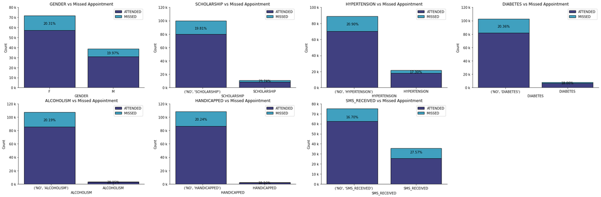

```python
# Assigning n with the value of 0, and then shall be used inside the loop to adhust the index of the subplots
n = 0
# Setting the figure size
plt.figure(figsize=[32, 10])
# Using a for loop to loop over all the varibales using the custom funciton graph_n_pct
for k in df_raw.columns:
    # Condition to skip numenrical variables
    if 2 < df_raw.groupby(k)['missed_appoint'].value_counts().shape[0] < 5:
        # Adding 1 to n for every loop, then use in as an index in the subplot aurgment latter.
        n = 1 + n
        plt.subplot(2, 4, n)
        # using the custom fucntion graph_n_pct to plot and calcualte the required percentages
        graph_n_pct(df_raw, k, 'missed_appoint',
                    df_raw[k].name, df_raw[k].name, 'Attended', 'Missed')
```

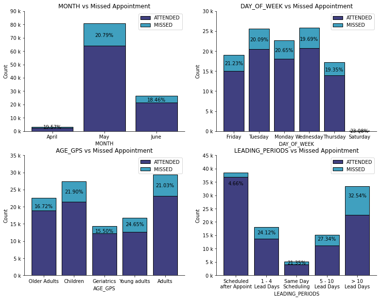

```python
# Assigning n with the value of 0, and then shall be used inside the loop to adhust the index of the subplots
n = 0
# Setting the figure size
plt.figure(figsize=[13, 10])
# Using a for loop to loop over all the varibales using the custom funciton graph_n_pct
for k in df_raw.columns:
    # Condition to skip numenrical variables
    if 4 < df_raw.groupby(k)['missed_appoint'].value_counts().shape[0] < 20:
        # Adding 1 to n for every loop, then use in as an index in the subplot aurgment latter.
        n = 1 + n
        plt.subplot(2, 2, n)
        # using the custom fucntion graph_n_pct to plot and calcualte the required percentages
        graph_n_pct(df_raw, k, 'missed_appoint',
                    df_raw[k].name, df_raw[k].name, 'Attended', 'Missed')
```

### Key Observations:

As we've see in the univariate exploration, that the overall missed appointment percent% is 20%, so any subgroup of each and all of the categorical variable that has less or more significant percentages; will be further investigated for correlation with the dependent variable.

This excercise expresses the importance of studying the relationship between 2 or more variables at once; to be able to observe and interpret the right insights;

For example:

- We can see that most of the subgroups missed appointment proportions are similar to the average of 20% except for:  
  #### Remarkebly Below Average:

  ```
   * Hypertension, Diabetic, Handicapped, older Adults and Geriatric Patients.
  ```

  #### Remarkebly Above Average:

  ```
   * sms_received, Young Adults, 1-4 and 5-10 and over 10 leading days before appointment Patients.
  ```

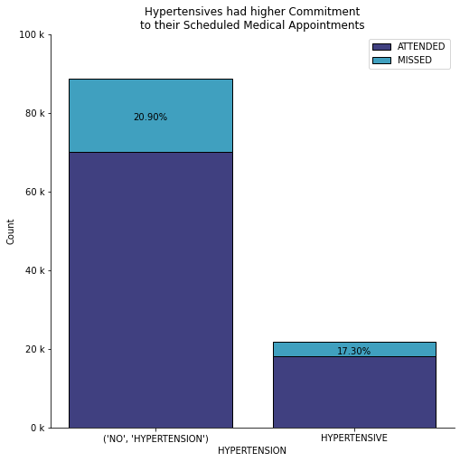

```python
plt.figure(figsize=[8, 8])
graph_n_pct(df_raw, 'hypertension', 'missed_appoint',
            'Hypertension', 'Hypertensive', 'Attended', 'Missed')

plt.title('Hypertensives had higher Commitment\nto their Scheduled Medical Appointments');
```

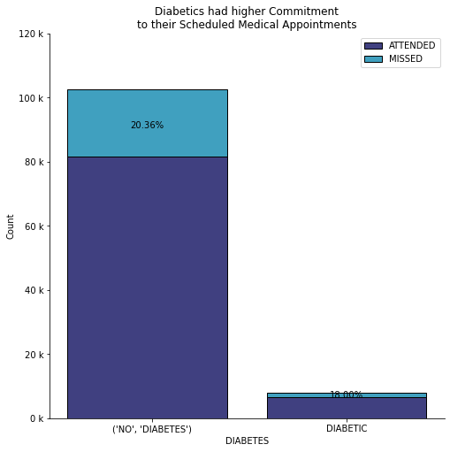

```python
plt.figure(figsize=[8, 8])

graph_n_pct(df_raw, 'diabetes', 'missed_appoint',
            'Diabetes', 'diabetic', 'Attended', 'Missed')
plt.title('Diabetics had higher Commitment\nto their Scheduled Medical Appointments');
```

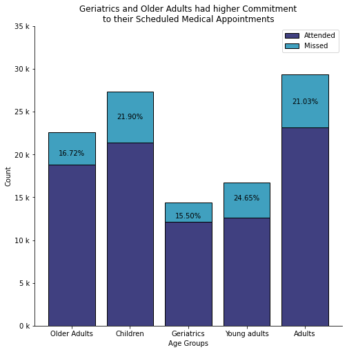

```python
plt.figure(figsize=[8, 8])

ax = sb.histplot(data=df_raw, x='age_gps', stat='count', hue='missed_appoint', multiple='stack',
                 discrete=True, shrink=0.8, hue_order=[True, False], palette='ocean_r')
plt.legend(['Attended', 'Missed'])
plt.xlabel(df_raw.age_gps.name.upper())

pct = df_raw.groupby('age_gps')['missed_appoint'].value_counts(1)
counts_bv = df_raw.age_gps.value_counts()
sb.despine()
for u in df_raw.age_gps.value_counts().index:
    count = counts_bv.loc[u]
    pct_bv = '{:0.2f}%'.format(100*pct[u][1])
    plt.text(u, count*.89, pct_bv, ha='center', va='center')

# plt.yticks(np.arange(df[c1]))
# import warnings
# warnings.filterwarnings("default")
ax.set_yticks(ax.get_yticks().tolist())
ax.set_yticklabels(['{:,} k'.format(int(x/1000))
                    for x in ax.get_yticks().tolist()])
plt.xlabel('Age Groups')
plt.title('Geriatrics and Older Adults had higher Commitment\nto their Scheduled Medical Appointments');
```

[figure not shown]

```python
plt.figure(figsize=[8, 8])

graph_n_pct(df_raw, 'leading_periods', 'missed_appoint',
            'leading_periods', 'leading_periods', 'Attended', 'Missed')
plt.title('Patients with Shorter Leading Periods(<10 days) showed higher\nCommitment to their Scheduled Medical Appointments');
```

### Thorugh the Uni- and Bi- variate exploration we've observed some correlation between the following individual variables and Missed Appointment "Dependent Variable":

- Age Groups
- Leading Days
- weak correlation with Receiving sms.
- Comorbidities with Hypertension, Diabetes and being Handicapped.

## MultiVariate Exploration:

After we've already spotted some correlation between some individual variables and our dependent variable, now we are going to investigate weather these prelimnary insights would vary if we added some other variable or not.

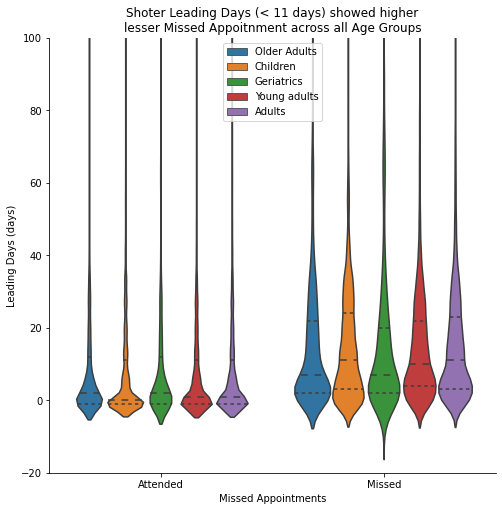

```python
plt.figure(figsize=[8, 8])

ax=sb.violinplot(y=df_raw.leading_days  , hue=df_raw.age_gps, x=df_raw.missed_appoint,whis=2.5, fliersize=.5, inner='quart')
plt.ylim(-20,100)
plt.title('Shoter Leading Days (< 11 days) showed higher\nlesser Missed Appoitnment across all Age Groups')
plt.legend(loc=9)
ax.set_xlabel('Missed Appointments')
ax.set_ylabel('Leading Days (days)')

ax.set_xticklabels(["Attended", "Missed"])
sb.despine();
```

#### `Higher median leading days were observed in the missed apppintments gruops across all age groups.`

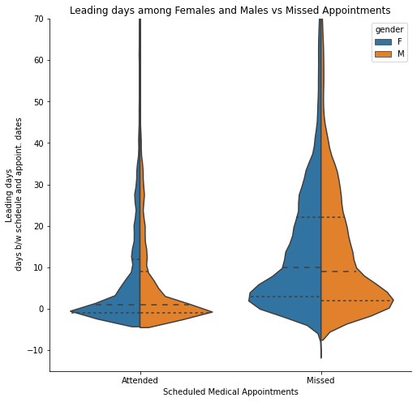

```python
plt.figure(figsize=[8, 8])

ax2 = sb.violinplot(y=df_raw.leading_days, x=df_raw.missed_appoint,
                    fliersize=1, hue=df_raw.gender, inner='quart', split=True)
plt.ylim(-15, 70)
ax2.set_xticklabels(['Attended', 'Missed'])
plt.title('Leading days among Females and Males vs Missed Appointments')
plt.xlabel('Scheduled Medical Appointments')
plt.ylabel('Leading days\n days b/w schdeule and appoint. dates')


sb.despine();
```

From the previous violin chart, we can observe that the median leading days for female and male who attended patients (1 , 1) is much lower than missed patients (10, and 9), regardless of the gender.

In addition, 3rd quartile of female and male patients who attended their appointments had leading days of (12, and 9 with average of 11) and this was much lower than of who missed the appoitments (22, and 22), respectively; suggeting that:

### `longer leading days (days between scheduling date and appointments date) than 11 days may lead to higher missed appointments regardless of gender`.

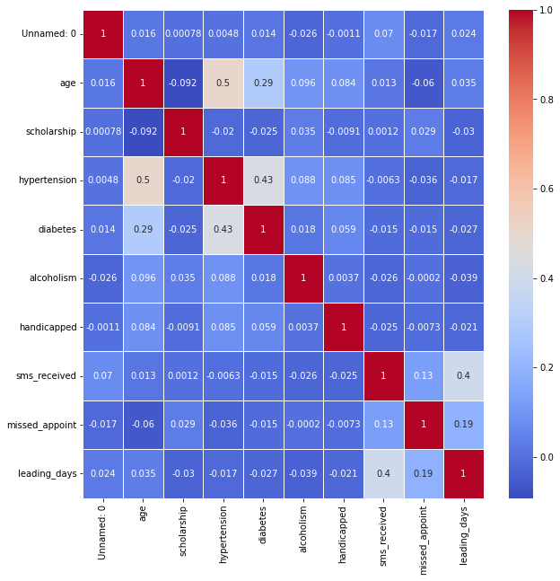

```python
plt.figure(figsize=(10, 10))
sb.heatmap(df_raw.corr(), annot=True, cmap='coolwarm', linewidths=1);
```

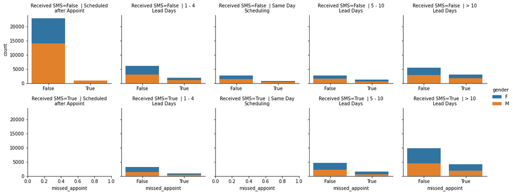

```python
plt.figure(figsize=(32,8))
g = sb.FacetGrid(data=df_raw, col='leading_periods', hue='gender', hue_order=["F", "M"], row='sms_received',  sharex=False);
g.map(sb.countplot, 'missed_appoint', order=[False, True]).add_legend();

g.set_titles(col_template='{col_name}', row_template='Received SMS={row_name} ');
```

From the previous chart, we can conclude that

### `Receiving sms by patients that had leading days of 5 days and above was positively correlated with higher attendance rates`,

# Summary:

### * comorbidities with hypertension, diabeted or handicapped patients had fewer missed appointments rates than normal patients.

# `Take home Message (Key Insight):`

### Focosing on the patients who had higher missed appointments rates such as younger ages, Patients wihout comorbidities with chronic diases such as hypertension and diabetes, by ensuring shorter leading days, and sms reminders at least 5 days and earlier to the appointment day, shall improve their commitments and increase the planning accuracy and so, resources ultilization shall improve as well.`

# Limitations:

- We didsn't study neighbourhood, and the possible interaction between variables such as the comorbidity between hypertension and diabeted and so on.
- We didn't study the in-group differences among diffrent hadicapped categoreies.

> Once you're ready to finish your presentation, check your output by using nbconvert to export the notebook and set up a server for the slides. From the terminal or command line, use the following expression:

> > `jupyter nbconvert <file_name>.ipynb --to slides --post serve --template output_toggle`

> This should open a tab in your web browser where you can scroll through your presentation. Sub-slides can be accessed by pressing 'down' when viewing its parent slide. Make sure you remove all of the quote-formatted guide notes like this one before you finish your presentation!